# Separate Admixture analysis

## Lakes Brienz and Thun

### All species

#### Removing species with less than 10 individuals/samples

Additionally, keep only those species that are present in lakes Brienz and Thun.

```r
poptable <- read.table('~/cophyhopa/data/popmap.txt',
                       col.names = c('sample', 'group', 'pop', 'lake'))

poptable <- poptable[-which(poptable[,3] == "C.alpinus"), ]
poptable <- poptable[-which(poptable[,3] == "C.alpinus/C.steinmanni"), ]
poptable <- poptable[-which(poptable[,3] == "C.brienzii"), ]
poptable <- poptable[-which(poptable[,3] == "C.fatioi/C.albellus"), ]
poptable <- poptable[-which(poptable[,3] == "D"), ]
poptable <- poptable[-which(poptable[,3] == "L"), ]
poptable <- poptable[-which(poptable[,3] == "P"), ]
poptable <- poptable[-which(poptable[,3] == "C.duplex"), ]
poptable <- poptable[-which(poptable[,3] == "C.heglingus"), ]
poptable <- poptable[-which(poptable[,3] == "C.zuerichensis"), ]
poptable <- poptable[-which(poptable[,3] == "C.confusus"), ]
poptable <- poptable[-which(poptable[,3] == "C.brienzii/C.fatioi"), ]

write.table(poptable[,1], file = '~/cophyhopa/data/ADMX/BT_all.txt', quote = FALSE,
            row.names = FALSE, col.names = FALSE)
```

#### Data selecting and filtering

```bash
VCF='/gata/mar/cophyhopa/results/2022-05-04/assem2_indv2.recode.vcf'
FILE=BT_all
if [ ! -e $FILE.vcf.gz ]; then
   vcftools --vcf $VCF \
            --out dirty \
            --keep ~/cophyhopa/data/ADMX/BT_all.txt \
            --recode \
            --recode-INFO-all
   vcftools --vcf dirty.recode.vcf \
            --out $FILE \
            --thin 500 \
            --remove-indels \
            --mac 2 \
            --max-alleles 2 \
            --max-meanDP 1000 \
            --max-missing-count 7 \
            --stdout \
            --recode --recode-INFO-all \
            | gzip > $FILE.vcf.gz
fi
if [ -e dirty.recode.vcf ]; then rm dirty.recode.vcf; fi

if [ ! -e chromMap.txt ]; then
   gunzip -c $FILE".vcf.gz" | \
   gawk '(/^[^#]/){
      A[$1] = 1
   }END{
      N = 1
      for (chr in A) {
         print chr "\t" N
         N = N + 1
      }
   }' > chromMap.txt
fi

vcftools --gzvcf $FILE".vcf.gz" \
         --plink --mac 2 --remove-indels --max-alleles 2 \
         --chrom-map chromMap.txt \
         --out $FILE

gawk -v OFS="\t" '{
   $1 = 1
   $2 = 1 ":" $4
   print $0
}' $FILE".map" > better.map
mv better.map $FILE.map

plink --file $FILE --make-bed --out $FILE --allow-no-sex --allow-extra-chr 0
```

```
##
## VCFtools - 0.1.17
## (C) Adam Auton and Anthony Marcketta 2009
##
## Parameters as interpreted:
##  --vcf /gata/mar/cophyhopa/results/2022-05-04/assem2_indv2.recode.vcf
##  --keep /gata/mar/cophyhopa/data/ADMX/BT_all.txt
##  --recode-INFO-all
##  --out dirty
##  --recode
##
## Keeping individuals in 'keep' list
## After filtering, kept 80 out of 271 Individuals
## Outputting VCF file...
## After filtering, kept 879238 out of a possible 879238 Sites
## Run Time = 125.00 seconds
##
## VCFtools - 0.1.17
## (C) Adam Auton and Anthony Marcketta 2009
##
## Parameters as interpreted:
##  --vcf dirty.recode.vcf
##  --recode-INFO-all
##  --mac 2
##  --max-alleles 2
##  --max-missing-count 7
##  --max-meanDP 1e+03
##  --thin 500
##  --out BT_all
##  --recode
##  --remove-indels
##  --stdout
##
## After filtering, kept 80 out of 80 Individuals
## Outputting VCF file...
## After filtering, kept 25568 out of a possible 879238 Sites
## Run Time = 23.00 seconds
##
## VCFtools - 0.1.17
## (C) Adam Auton and Anthony Marcketta 2009
```

[output cut: 29 more lines]

```
.ped scan complete (for binary autoconversion).
## Performing single-pass .bed write (25568 variants, 80 people).
## 0%1%2%3%4%5%6%7%8%9%10%11%12%13%14%15%16%17%18%19%20%21%22%23%24%25%26%27%28%29%30%31%32%33%34%35%36%37%38%39%40%41%42%43%44%45%46%47%48%49%50%51%52%53%54%55%56%57%58%59%60%61%62%63%64%65%66%67%68%69%70%71%72%73%74%75%76%77%78%79%80%81%82%83%84%85%86%87%88%89%90%91%92%93%94%
--file: BT_all-temporary.bed + BT_all-temporary.bim + BT_all-temporary.fam
## written.
## 25568 variants loaded from .bim file.
## 80 people (0 males, 0 females, 80 ambiguous) loaded from .fam.
## Ambiguous sex IDs written to BT_all.nosex .
## Using 1 thread (no multithreaded calculations invoked).
## Before main variant filters, 80 founders and 0 nonfounders present.
## Calculating allele frequencies... 0%1%2%3%4%5%6%7%8%9%10%11%12%13%14%15%16%17%18%19%20%21%22%23%24%25%26%27%28%29%30%31%32%33%34%35%36%37%38%39%40%41%42%43%44%45%46%47%48%49%50%51%52%53%54%55%56%57%58%59%60%61%62%63%64%65%66%67%68%69%70%71%72%73%74%75%76%77%78%79%80%81%82%83%84%85%86%87%88%89%90%…
## Total genotyping rate is 0.98788.
## 25568 variants and 80 people pass filters and QC.
## Note: No phenotypes present.
## --make-bed to BT_all.bed + BT_all.bim + BT_all.fam ... 0%1%2%3%4%5%6%7%8%9%10%11%12%13%14%15%16%17%18%19%20%21%22%23%24%25%26%27%28%29%30%31%32%33%34%35%36%37%38%39%40%41%42%43%44%45%46%47%48%49%50%51%52%53%54%55%56%57%58%59%60%61%62%63%64%65%66%67%68%69%70%71%72%73%74%75%76%77%78%79%80%81%82%83%…
```

#### Admixture analysis with variant K

We define the K parameter from 4 to 6, computing the cross-validation error. Then, we extract these values.

```bash
INPUT='/gata/mar/cophyhopa/results/2022-05-09/admixture/ALPINE/BT_all.bed'

for K in 4 5 6; do
  if [ ! -e log${K}.BT_all.out ]; then
    admixture --cv $INPUT $K | tee log${K}.BT_all.out;
  fi
done
```

```bash
grep -h CV log*.BT_all.out
```

```
## CV error (K=4): 0.43703
## CV error (K=5): 0.46533
## CV error (K=6): 0.50438
```

#### Plot Q estimates for K = 4, 5 and 6

We choose the K that has given a lower value of the cross-validation error. We add the sample names and display a barplot

[output not shown]

[output cut: 104 more lines]

[output not shown]

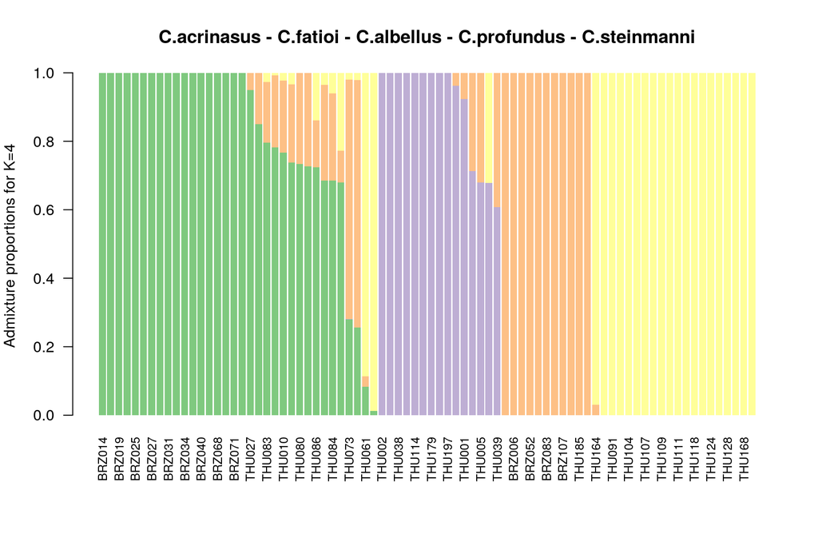

[output not shown]

[output cut: 104 more lines]

[output not shown]

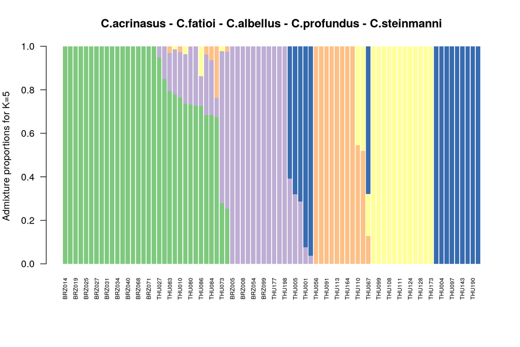

[output not shown]

[output cut: 104 more lines]

[output not shown]

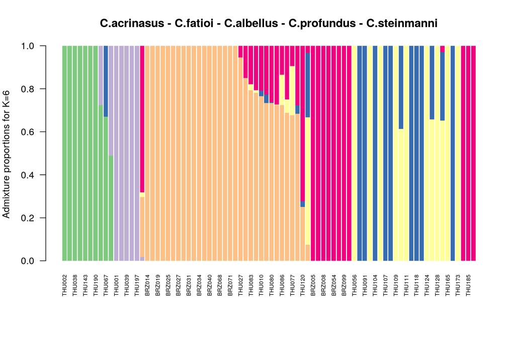

### C.acrinasus - C.fatioi - C.albellus - C.profundus

We exclude C.steinmanni because it seems to have the more confuse association in clusters.

#### Removing species with less than 10 individuals/samples

Additionally, keep only those species that are present in lakes Brienz and Thun.

```r
poptable <- read.table('~/cophyhopa/data/popmap.txt',
                       col.names = c('sample', 'group', 'pop', 'lake'))

poptable <- poptable[-which(poptable[,3] == "C.alpinus"), ]
poptable <- poptable[-which(poptable[,3] == "C.alpinus/C.steinmanni"), ]
poptable <- poptable[-which(poptable[,3] == "C.brienzii"), ]
poptable <- poptable[-which(poptable[,3] == "C.fatioi/C.albellus"), ]
poptable <- poptable[-which(poptable[,3] == "D"), ]
poptable <- poptable[-which(poptable[,3] == "L"), ]
poptable <- poptable[-which(poptable[,3] == "P"), ]
poptable <- poptable[-which(poptable[,3] == "C.duplex"), ]
poptable <- poptable[-which(poptable[,3] == "C.heglingus"), ]
poptable <- poptable[-which(poptable[,3] == "C.zuerichensis"), ]
poptable <- poptable[-which(poptable[,3] == "C.confusus"), ]
poptable <- poptable[-which(poptable[,3] == "C.brienzii/C.fatioi"), ]
poptable <- poptable[-which(poptable[,3] == "C.steinmanni"), ]

write.table(poptable[,1], file = '~/cophyhopa/data/ADMX/BT_afap.txt', quote = FALSE,
            row.names = FALSE, col.names = FALSE)
```

#### Data selecting and filtering

```bash
VCF='/gata/mar/cophyhopa/results/2022-05-04/assem2_indv2.recode.vcf'
FILE=BT_afap
if [ ! -e $FILE.vcf.gz ]; then
   vcftools --vcf $VCF \
            --out dirty \
            --keep ~/cophyhopa/data/ADMX/BT_afap.txt \
            --recode \
            --recode-INFO-all
   vcftools --vcf dirty.recode.vcf \
            --out $FILE \
            --thin 500 \
            --remove-indels \
            --mac 2 \
            --max-alleles 2 \
            --max-meanDP 1000 \
            --max-missing-count 7 \
            --stdout \
            --recode --recode-INFO-all \
            | gzip > $FILE.vcf.gz
fi
if [ -e dirty.recode.vcf ]; then rm dirty.recode.vcf; fi

if [ ! -e chromMap.txt ]; then
   gunzip -c $FILE".vcf.gz" | \
   gawk '(/^[^#]/){
      A[$1] = 1
   }END{
      N = 1
      for (chr in A) {
         print chr "\t" N
         N = N + 1
      }
   }' > chromMap.txt
fi

vcftools --gzvcf $FILE".vcf.gz" \
         --plink --mac 2 --remove-indels --max-alleles 2 \
         --chrom-map chromMap.txt \
         --out $FILE

gawk -v OFS="\t" '{
   $1 = 1
   $2 = 1 ":" $4
   print $0
}' $FILE".map" > better.map
mv better.map $FILE.map

plink --file $FILE --make-bed --out $FILE --allow-no-sex --allow-extra-chr 0
```

```
##
## VCFtools - 0.1.17
## (C) Adam Auton and Anthony Marcketta 2009
##
## Parameters as interpreted:
##  --vcf /gata/mar/cophyhopa/results/2022-05-04/assem2_indv2.recode.vcf
##  --keep /gata/mar/cophyhopa/data/ADMX/BT_afap.txt
##  --recode-INFO-all
##  --out dirty
##  --recode
##
## Keeping individuals in 'keep' list
## After filtering, kept 70 out of 271 Individuals
## Outputting VCF file...
## After filtering, kept 879238 out of a possible 879238 Sites
## Run Time = 119.00 seconds
##
## VCFtools - 0.1.17
## (C) Adam Auton and Anthony Marcketta 2009
##
## Parameters as interpreted:
##  --vcf dirty.recode.vcf
##  --recode-INFO-all
##  --mac 2
##  --max-alleles 2
##  --max-missing-count 7
##  --max-meanDP 1e+03
##  --thin 500
##  --out BT_afap
##  --recode
##  --remove-indels
##  --stdout
##
## After filtering, kept 70 out of 70 Individuals
## Outputting VCF file...
## After filtering, kept 25556 out of a possible 879238 Sites
## Run Time = 21.00 seconds
##
## VCFtools - 0.1.17
## (C) Adam Auton and Anthony Marcketta 2009
```

[output cut: 29 more lines]

```
.ped scan complete (for binary autoconversion).
## Performing single-pass .bed write (25556 variants, 70 people).
## 0%1%2%3%4%5%6%7%8%9%10%11%12%13%14%15%16%17%18%19%20%21%22%23%24%25%26%27%28%29%30%31%32%33%34%35%36%37%38%39%40%41%42%43%44%45%46%47%48%49%50%51%52%53%54%55%56%57%58%59%60%61%62%63%64%65%66%67%68%69%70%71%72%73%74%75%76%77%78%79%80%81%82%83%84%85%86%87%88%89%90%91%92%93%94%
--file: BT_afap-temporary.bed + BT_afap-temporary.bim + BT_afap-temporary.fam
## written.
## 25556 variants loaded from .bim file.
## 70 people (0 males, 0 females, 70 ambiguous) loaded from .fam.
## Ambiguous sex IDs written to BT_afap.nosex .
## Using 1 thread (no multithreaded calculations invoked).
## Before main variant filters, 70 founders and 0 nonfounders present.
## Calculating allele frequencies... 0%1%2%3%4%5%6%7%8%9%10%11%12%13%14%15%16%17%18%19%20%21%22%23%24%25%26%27%28%29%30%31%32%33%34%35%36%37%38%39%40%41%42%43%44%45%46%47%48%49%50%51%52%53%54%55%56%57%58%59%60%61%62%63%64%65%66%67%68%69%70%71%72%73%74%75%76%77%78%79%80%81%82%83%84%85%86%87%88%89%90%…
## Total genotyping rate is 0.986056.
## 25556 variants and 70 people pass filters and QC.
## Note: No phenotypes present.
## --make-bed to BT_afap.bed + BT_afap.bim + BT_afap.fam ... 0%1%2%3%4%5%6%7%8%9%10%11%12%13%14%15%16%17%18%19%20%21%22%23%24%25%26%27%28%29%30%31%32%33%34%35%36%37%38%39%40%41%42%43%44%45%46%47%48%49%50%51%52%53%54%55%56%57%58%59%60%61%62%63%64%65%66%67%68%69%70%71%72%73%74%75%76%77%78%79%80%81%82%…
```

#### Admixture analysis with variant K

We define the K parameter from 3 to 5, computing the cross-validation error. Then, we extract these values.

```bash
INPUT='/gata/mar/cophyhopa/results/2022-05-09/admixture/ALPINE/BT_afap.bed'

for K in 3 4 5; do
  if [ ! -e log${K}.BT_afap.out ]; then
    admixture --cv $INPUT $K | tee log${K}.BT_afap.out;
  fi
done
```

```bash
grep -h CV log*.BT_afap.out
```

```
## CV error (K=3): 0.44847
## CV error (K=4): 0.46925
## CV error (K=5): 0.49890
```

#### Plot Q estimates for K = 3, 4 and 5

We choose the K that has given a lower value of the cross-validation error. We add the sample names and display a barplot

[output not shown]

[output cut: 84 more lines]

[output not shown]

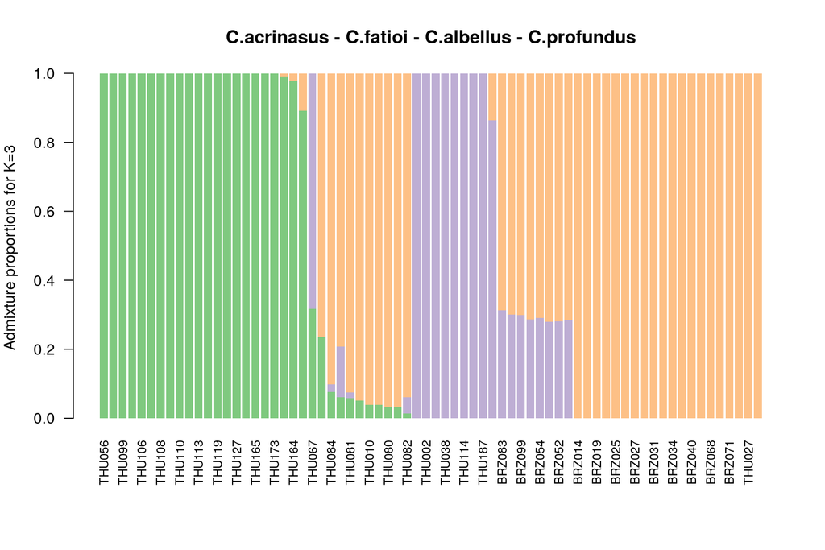

[output not shown]

[output cut: 84 more lines]

[output not shown]

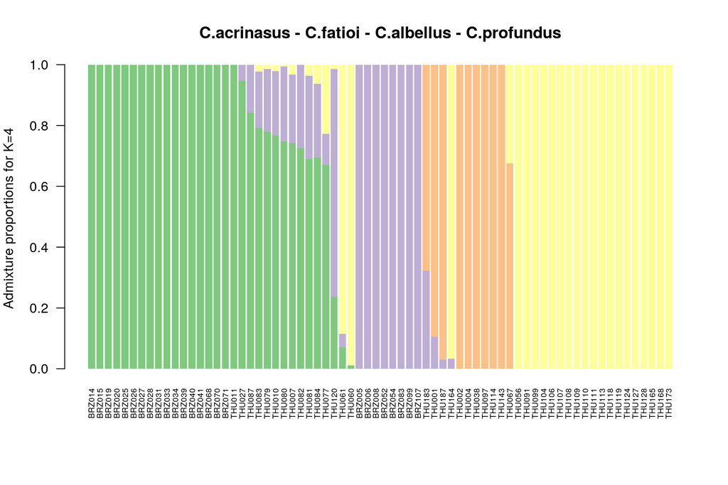

[output not shown]

[output cut: 84 more lines]

[output not shown]

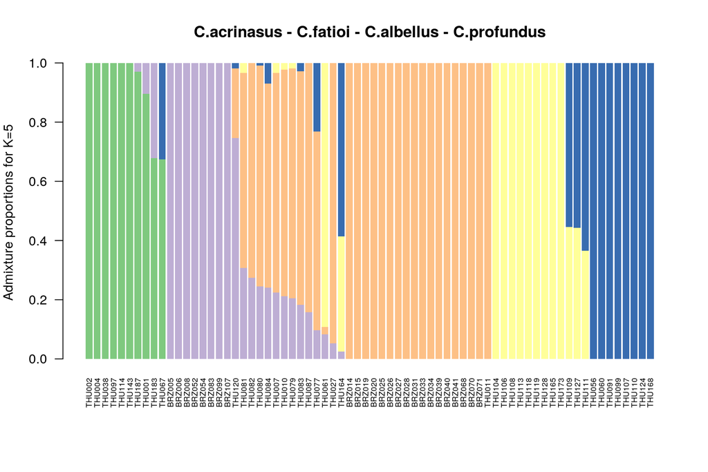

### C.acrinasus - C.fatioi - C.albellus

We exclude C.profundus because it seems to be a clearly cluster itself.

#### Removing species with less than 10 individuals/samples

Additionally, keep only those species that are present in lakes Brienz and Thun.

```r
poptable <- read.table('~/cophyhopa/data/popmap.txt',
                       col.names = c('sample', 'group', 'pop', 'lake'))

poptable <- poptable[-which(poptable[,3] == "C.alpinus"), ]
poptable <- poptable[-which(poptable[,3] == "C.alpinus/C.steinmanni"), ]
poptable <- poptable[-which(poptable[,3] == "C.brienzii"), ]
poptable <- poptable[-which(poptable[,3] == "C.fatioi/C.albellus"), ]
poptable <- poptable[-which(poptable[,3] == "D"), ]
poptable <- poptable[-which(poptable[,3] == "L"), ]
poptable <- poptable[-which(poptable[,3] == "P"), ]
poptable <- poptable[-which(poptable[,3] == "C.duplex"), ]
poptable <- poptable[-which(poptable[,3] == "C.heglingus"), ]
poptable <- poptable[-which(poptable[,3] == "C.zuerichensis"), ]
poptable <- poptable[-which(poptable[,3] == "C.confusus"), ]
poptable <- poptable[-which(poptable[,3] == "C.brienzii/C.fatioi"), ]

poptable <- poptable[-which(poptable[,3] == "C.steinmanni"), ]
poptable <- poptable[-which(poptable[,3] == "C.profundus"), ]

write.table(poptable[,1], file = '~/cophyhopa/data/ADMX/BT_afa.txt', quote = FALSE,
            row.names = FALSE, col.names = FALSE)
```

#### Data selecting and filtering

```bash
VCF='/gata/mar/cophyhopa/results/2022-05-04/assem2_indv2.recode.vcf'
FILE=BT_afa
if [ ! -e $FILE.vcf.gz ]; then
   vcftools --vcf $VCF \
            --out dirty \
            --keep ~/cophyhopa/data/ADMX/BT_afa.txt \
            --recode \
            --recode-INFO-all
   vcftools --vcf dirty.recode.vcf \
            --out $FILE \
            --thin 500 \
            --remove-indels \
            --mac 2 \
            --max-alleles 2 \
            --max-meanDP 1000 \
            --max-missing-count 7 \
            --stdout \
            --recode --recode-INFO-all \
            | gzip > $FILE.vcf.gz
fi
if [ -e dirty.recode.vcf ]; then rm dirty.recode.vcf; fi

if [ ! -e chromMap.txt ]; then
   gunzip -c $FILE".vcf.gz" | \
   gawk '(/^[^#]/){
      A[$1] = 1
   }END{
      N = 1
      for (chr in A) {
         print chr "\t" N
         N = N + 1
      }
   }' > chromMap.txt
fi

vcftools --gzvcf $FILE".vcf.gz" \
         --plink --mac 2 --remove-indels --max-alleles 2 \
         --chrom-map chromMap.txt \
         --out $FILE

gawk -v OFS="\t" '{
   $1 = 1
   $2 = 1 ":" $4
   print $0
}' $FILE".map" > better.map
mv better.map $FILE.map

plink --file $FILE --make-bed --out $FILE --allow-no-sex --allow-extra-chr 0
```

```
##
## VCFtools - 0.1.17
## (C) Adam Auton and Anthony Marcketta 2009
##
## Parameters as interpreted:
##  --vcf /gata/mar/cophyhopa/results/2022-05-04/assem2_indv2.recode.vcf
##  --keep /gata/mar/cophyhopa/data/ADMX/BT_afa.txt
##  --recode-INFO-all
##  --out dirty
##  --recode
##
## Keeping individuals in 'keep' list
## After filtering, kept 48 out of 271 Individuals
## Outputting VCF file...
## After filtering, kept 879238 out of a possible 879238 Sites
## Run Time = 105.00 seconds
##
## VCFtools - 0.1.17
## (C) Adam Auton and Anthony Marcketta 2009
##
## Parameters as interpreted:
##  --vcf dirty.recode.vcf
##  --recode-INFO-all
##  --mac 2
##  --max-alleles 2
##  --max-missing-count 7
##  --max-meanDP 1e+03
##  --thin 500
##  --out BT_afa
##  --recode
##  --remove-indels
##  --stdout
##
## After filtering, kept 48 out of 48 Individuals
## Outputting VCF file...
## After filtering, kept 26891 out of a possible 879238 Sites
## Run Time = 15.00 seconds
##
## VCFtools - 0.1.17
## (C) Adam Auton and Anthony Marcketta 2009
```

[output cut: 29 more lines]

```
.ped scan complete (for binary autoconversion).
## Performing single-pass .bed write (26891 variants, 48 people).
## 0%1%2%3%4%5%6%7%8%9%10%11%12%13%14%15%16%17%18%19%20%21%22%23%24%25%26%27%28%29%30%31%32%33%34%35%36%37%38%39%40%41%42%43%44%45%46%47%48%49%50%51%52%53%54%55%56%57%58%59%60%61%62%63%64%65%66%67%68%69%70%71%72%73%74%75%76%77%78%79%80%81%82%83%84%85%86%87%88%89%90%91%92%93%94%
--file: BT_afa-temporary.bed + BT_afa-temporary.bim + BT_afa-temporary.fam
## written.
## 26891 variants loaded from .bim file.
## 48 people (0 males, 0 females, 48 ambiguous) loaded from .fam.
## Ambiguous sex IDs written to BT_afa.nosex .
## Using 1 thread (no multithreaded calculations invoked).
## Before main variant filters, 48 founders and 0 nonfounders present.
## Calculating allele frequencies... 0%1%2%3%4%5%6%7%8%9%10%11%12%13%14%15%16%17%18%19%20%21%22%23%24%25%26%27%28%29%30%31%32%33%34%35%36%37%38%39%40%41%42%43%44%45%46%47%48%49%50%51%52%53%54%55%56%57%58%59%60%61%62%63%64%65%66%67%68%69%70%71%72%73%74%75%76%77%78%79%80%81%82%83%84%85%86%87%88%89%90%…
## Total genotyping rate is 0.980994.
## 26891 variants and 48 people pass filters and QC.
## Note: No phenotypes present.
## --make-bed to BT_afa.bed + BT_afa.bim + BT_afa.fam ... 0%1%2%3%4%5%6%7%8%9%10%11%12%13%14%15%16%17%18%19%20%21%22%23%24%25%26%27%28%29%30%31%32%33%34%35%36%37%38%39%40%41%42%43%44%45%46%47%48%49%50%51%52%53%54%55%56%57%58%59%60%61%62%63%64%65%66%67%68%69%70%71%72%73%74%75%76%77%78%79%80%81%82%83%…
```

#### Admixture analysis with variant K

We define the K parameter from 2 to 4, computing the cross-validation error. Then, we extract these values.

```bash
INPUT='/gata/mar/cophyhopa/results/2022-05-09/admixture/ALPINE/BT_afa.bed'

for K in 2 3 4; do
  if [ ! -e log${K}.BT_afa.out ]; then
    admixture --cv $INPUT $K | tee log${K}.BT_afa.out;
  fi
done
```

```bash
grep -h CV log*.BT_afa.out
```

```
## CV error (K=2): 0.50060
## CV error (K=3): 0.53476
## CV error (K=4): 0.62421
```

#### Plot Q estimates for K = 2, 3 and 4

We choose the K that has given a lower value of the cross-validation error. We add the sample names and display a barplot.

[output not shown]

[output cut: 40 more lines]

[output not shown]

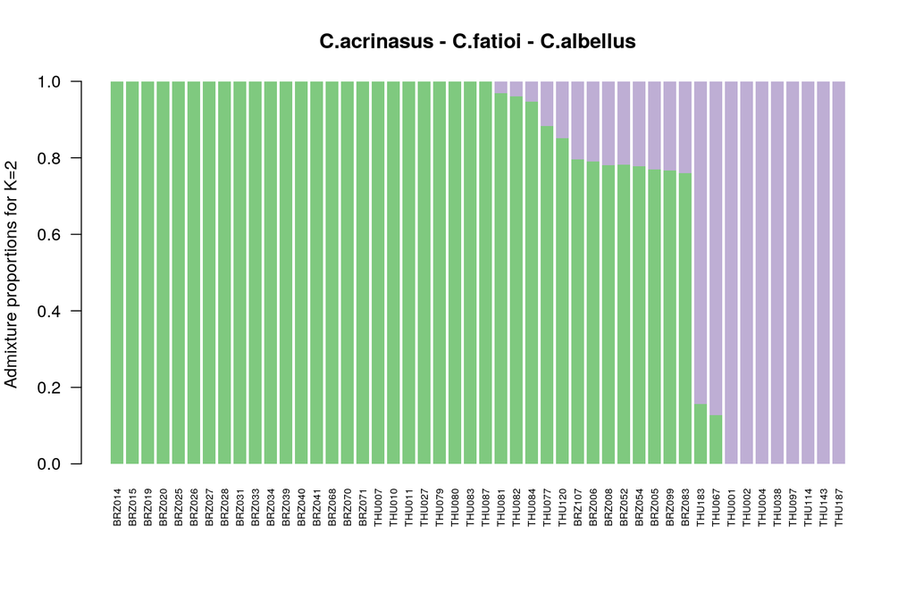

[output not shown]

[output cut: 40 more lines]

[output not shown]

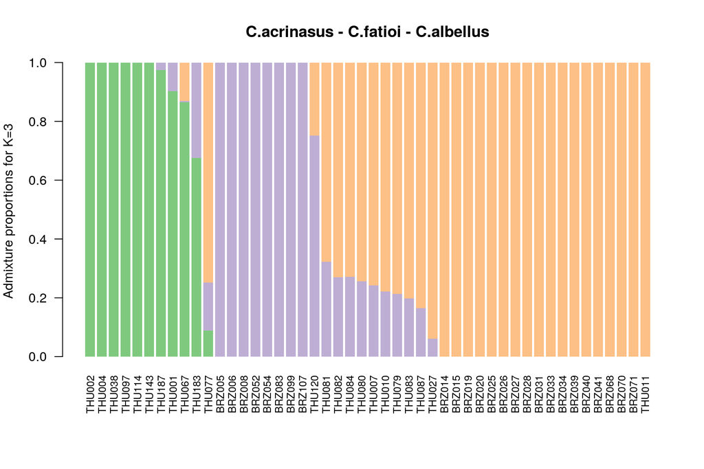

[output not shown]

[output cut: 40 more lines]

[output not shown]

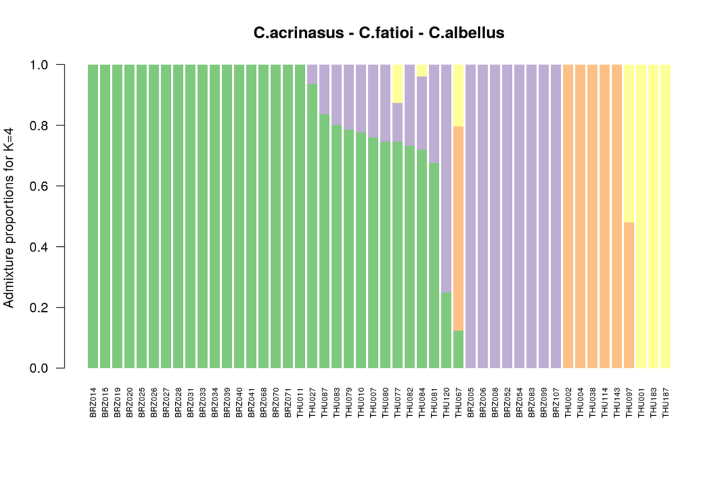

### C.fatioi - C.albellus

Now, we exclude C.acrinasus because it seems to be confused with C.albellus. We gonna exclude those 2 species to observe the classification without one or the other.

#### Removing species with less than 10 individuals/samples

Additionally, keep only those species that are present in lakes Brienz and Thun.

```r
poptable <- read.table('~/cophyhopa/data/popmap.txt',
                       col.names = c('sample', 'group', 'pop', 'lake'))

poptable <- poptable[-which(poptable[,3] == "C.alpinus"), ]
poptable <- poptable[-which(poptable[,3] == "C.alpinus/C.steinmanni"), ]
poptable <- poptable[-which(poptable[,3] == "C.brienzii"), ]
poptable <- poptable[-which(poptable[,3] == "C.fatioi/C.albellus"), ]
poptable <- poptable[-which(poptable[,3] == "D"), ]
poptable <- poptable[-which(poptable[,3] == "L"), ]
poptable <- poptable[-which(poptable[,3] == "P"), ]
poptable <- poptable[-which(poptable[,3] == "C.duplex"), ]
poptable <- poptable[-which(poptable[,3] == "C.heglingus"), ]
poptable <- poptable[-which(poptable[,3] == "C.zuerichensis"), ]
poptable <- poptable[-which(poptable[,3] == "C.confusus"), ]
poptable <- poptable[-which(poptable[,3] == "C.brienzii/C.fatioi"), ]

poptable <- poptable[-which(poptable[,3] == "C.steinmanni"), ]
poptable <- poptable[-which(poptable[,3] == "C.profundus"), ]
poptable <- poptable[-which(poptable[,3] == "C.acrinasus"), ]

write.table(poptable[,1], file = '~/cophyhopa/data/ADMX/BT_fa.txt', quote = FALSE,
            row.names = FALSE, col.names = FALSE)
```

#### Data selecting and filtering

```bash
VCF='/gata/mar/cophyhopa/results/2022-05-04/assem2_indv2.recode.vcf'
FILE=BT_fa
if [ ! -e $FILE.vcf.gz ]; then
   vcftools --vcf $VCF \
            --out dirty \
            --keep ~/cophyhopa/data/ADMX/BT_fa.txt \
            --recode \
            --recode-INFO-all
   vcftools --vcf dirty.recode.vcf \
            --out $FILE \
            --thin 500 \
            --remove-indels \
            --mac 2 \
            --max-alleles 2 \
            --max-meanDP 1000 \
            --max-missing-count 7 \
            --stdout \
            --recode --recode-INFO-all \
            | gzip > $FILE.vcf.gz
fi
if [ -e dirty.recode.vcf ]; then rm dirty.recode.vcf; fi

if [ ! -e chromMap.txt ]; then
   gunzip -c $FILE".vcf.gz" | \
   gawk '(/^[^#]/){
      A[$1] = 1
   }END{
      N = 1
      for (chr in A) {
         print chr "\t" N
         N = N + 1
      }
   }' > chromMap.txt
fi

vcftools --gzvcf $FILE".vcf.gz" \
         --plink --mac 2 --remove-indels --max-alleles 2 \
         --chrom-map chromMap.txt \
         --out $FILE

gawk -v OFS="\t" '{
   $1 = 1
   $2 = 1 ":" $4
   print $0
}' $FILE".map" > better.map
mv better.map $FILE.map

plink --file $FILE --make-bed --out $FILE --allow-no-sex --allow-extra-chr 0
```

```
##
## VCFtools - 0.1.17
## (C) Adam Auton and Anthony Marcketta 2009
##
## Parameters as interpreted:
##  --vcf /gata/mar/cophyhopa/results/2022-05-04/assem2_indv2.recode.vcf
##  --keep /gata/mar/cophyhopa/data/ADMX/BT_fa.txt
##  --recode-INFO-all
##  --out dirty
##  --recode
##
## Keeping individuals in 'keep' list
## After filtering, kept 38 out of 271 Individuals
## Outputting VCF file...
## After filtering, kept 879238 out of a possible 879238 Sites
## Run Time = 97.00 seconds
##
## VCFtools - 0.1.17
## (C) Adam Auton and Anthony Marcketta 2009
##
## Parameters as interpreted:
##  --vcf dirty.recode.vcf
##  --recode-INFO-all
##  --mac 2
##  --max-alleles 2
##  --max-missing-count 7
##  --max-meanDP 1e+03
##  --thin 500
##  --out BT_fa
##  --recode
##  --remove-indels
##  --stdout
##
## After filtering, kept 38 out of 38 Individuals
## Outputting VCF file...
## After filtering, kept 27142 out of a possible 879238 Sites
## Run Time = 13.00 seconds
##
## VCFtools - 0.1.17
## (C) Adam Auton and Anthony Marcketta 2009
```

[output cut: 29 more lines]

```
.ped scan complete (for binary autoconversion).
## Performing single-pass .bed write (27142 variants, 38 people).
## 0%1%2%3%4%5%6%7%8%9%10%11%12%13%14%15%16%17%18%19%20%21%22%23%24%25%26%27%28%29%30%31%32%33%34%35%36%37%38%39%40%41%42%43%44%45%46%47%48%49%50%51%52%53%54%55%56%57%58%59%60%61%62%63%64%65%66%67%68%69%70%71%72%73%74%75%76%77%78%79%80%81%82%83%84%85%86%87%88%89%90%91%92%93%94%
--file: BT_fa-temporary.bed + BT_fa-temporary.bim + BT_fa-temporary.fam
## written.
## 27142 variants loaded from .bim file.
## 38 people (0 males, 0 females, 38 ambiguous) loaded from .fam.
## Ambiguous sex IDs written to BT_fa.nosex .
## Using 1 thread (no multithreaded calculations invoked).
## Before main variant filters, 38 founders and 0 nonfounders present.
## Calculating allele frequencies... 0%1%2%3%4%5%6%7%8%9%10%11%12%13%14%15%16%17%18%19%20%21%22%23%24%25%26%27%28%29%30%31%32%33%34%35%36%37%38%39%40%41%42%43%44%45%46%47%48%49%50%51%52%53%54%55%56%57%58%59%60%61%62%63%64%65%66%67%68%69%70%71%72%73%74%75%76%77%78%79%80%81%82%83%84%85%86%87%88%89%90%…
## Total genotyping rate is 0.9792.
## 27142 variants and 38 people pass filters and QC.
## Note: No phenotypes present.
## --make-bed to BT_fa.bed + BT_fa.bim + BT_fa.fam ... 0%1%2%3%4%5%6%7%8%9%10%11%12%13%14%15%16%17%18%19%20%21%22%23%24%25%26%27%28%29%30%31%32%33%34%35%36%37%38%39%40%41%42%43%44%45%46%47%48%49%50%51%52%53%54%55%56%57%58%59%60%61%62%63%64%65%66%67%68%69%70%71%72%73%74%75%76%77%78%79%80%81%82%83%84%…
```

#### Admixture analysis with variant K

We define the K parameter from 2 to 3, computing the cross-validation error. Then, we extract these values.

```bash
INPUT='/gata/mar/cophyhopa/results/2022-05-09/admixture/ALPINE/BT_fa.bed'

for K in 2 3; do
  if [ ! -e log${K}.BT_fa.out ]; then
    admixture --cv $INPUT $K | tee log${K}.BT_fa.out;
  fi
done
```

```bash
grep -h CV log*.BT_fa.out
```

```
## CV error (K=2): 0.56838
## CV error (K=3): 0.64262
```

#### Plot Q estimates for K = 2 and 3

We choose the K that has given a lower value of the cross-validation error. We add the sample names and display a barplot.

[output not shown]

[output cut: 40 more lines]

[output not shown]

[figure not shown]

[output not shown]

[output cut: 40 more lines]

[output not shown]

[figure not shown]

We exclude C.profundus because it seems to be a clearly cluster itself.

#### Removing species with less than 10 individuals/samples

Additionally, keep only those species that are present in lakes Brienz and Thun.

```r
poptable <- read.table('~/cophyhopa/data/popmap.txt',
                       col.names = c('sample', 'group', 'pop', 'lake'))

poptable <- poptable[-which(poptable[,3] == "C.alpinus"), ]
poptable <- poptable[-which(poptable[,3] == "C.alpinus/C.steinmanni"), ]
poptable <- poptable[-which(poptable[,3] == "C.brienzii"), ]
poptable <- poptable[-which(poptable[,3] == "C.fatioi/C.albellus"), ]
poptable <- poptable[-which(poptable[,3] == "D"), ]
poptable <- poptable[-which(poptable[,3] == "L"), ]
poptable <- poptable[-which(poptable[,3] == "P"), ]
poptable <- poptable[-which(poptable[,3] == "C.duplex"), ]
poptable <- poptable[-which(poptable[,3] == "C.heglingus"), ]
poptable <- poptable[-which(poptable[,3] == "C.zuerichensis"), ]
poptable <- poptable[-which(poptable[,3] == "C.confusus"), ]
poptable <- poptable[-which(poptable[,3] == "C.brienzii/C.fatioi"), ]

poptable <- poptable[-which(poptable[,3] == "C.profundus"), ]
poptable <- poptable[-which(poptable[,3] == "C.albellus"), ]
poptable <- poptable[-which(poptable[,3] == "C.fatioi"), ]

write.table(poptable[,1], file = '~/cophyhopa/data/ADMX/BT_afs.txt', quote = FALSE,
            row.names = FALSE, col.names = FALSE)
```

#### Data selecting and filtering

```bash
VCF='/gata/mar/cophyhopa/results/2022-05-04/assem2_indv2.recode.vcf'
FILE=BT_afs
if [ ! -e $FILE.vcf.gz ]; then
   vcftools --vcf $VCF \
            --out dirty \
            --keep ~/cophyhopa/data/ADMX/BT_afs.txt \
            --recode \
            --recode-INFO-all
   vcftools --vcf dirty.recode.vcf \
            --out $FILE \
            --thin 500 \
            --remove-indels \
            --mac 2 \
            --max-alleles 2 \
            --max-meanDP 1000 \
            --max-missing-count 7 \
            --stdout \
            --recode --recode-INFO-all \
            | gzip > $FILE.vcf.gz
fi
if [ -e dirty.recode.vcf ]; then rm dirty.recode.vcf; fi

if [ ! -e chromMap.txt ]; then
   gunzip -c $FILE".vcf.gz" | \
   gawk '(/^[^#]/){
      A[$1] = 1
   }END{
      N = 1
      for (chr in A) {
         print chr "\t" N
         N = N + 1
      }
   }' > chromMap.txt
fi

vcftools --gzvcf $FILE".vcf.gz" \
         --plink --mac 2 --remove-indels --max-alleles 2 \
         --chrom-map chromMap.txt \
         --out $FILE

gawk -v OFS="\t" '{
   $1 = 1
   $2 = 1 ":" $4
   print $0
}' $FILE".map" > better.map
mv better.map $FILE.map

plink --file $FILE --make-bed --out $FILE --allow-no-sex --allow-extra-chr 0
```

```
##
## VCFtools - 0.1.17
## (C) Adam Auton and Anthony Marcketta 2009
##
## Parameters as interpreted:
##  --vcf /gata/mar/cophyhopa/results/2022-05-04/assem2_indv2.recode.vcf
##  --keep /gata/mar/cophyhopa/data/ADMX/BT_afs.txt
##  --recode-INFO-all
##  --out dirty
##  --recode
##
## Keeping individuals in 'keep' list
## After filtering, kept 20 out of 271 Individuals
## Outputting VCF file...
## After filtering, kept 879238 out of a possible 879238 Sites
## Run Time = 87.00 seconds
##
## VCFtools - 0.1.17
## (C) Adam Auton and Anthony Marcketta 2009
##
## Parameters as interpreted:
##  --vcf dirty.recode.vcf
##  --recode-INFO-all
##  --mac 2
##  --max-alleles 2
##  --max-missing-count 7
##  --max-meanDP 1e+03
##  --thin 500
##  --out BT_afs
##  --recode
##  --remove-indels
##  --stdout
##
## After filtering, kept 20 out of 20 Individuals
## Outputting VCF file...
## After filtering, kept 32520 out of a possible 879238 Sites
## Run Time = 9.00 seconds
##
## VCFtools - 0.1.17
## (C) Adam Auton and Anthony Marcketta 2009
```

[output cut: 29 more lines]

```
.ped scan complete (for binary autoconversion).
## Performing single-pass .bed write (32520 variants, 20 people).
## 0%1%2%3%4%5%6%7%8%9%10%11%12%13%14%15%16%17%18%19%20%21%22%23%24%25%26%27%28%29%30%31%32%33%34%35%36%37%38%39%40%41%42%43%44%45%46%47%48%49%50%51%52%53%54%55%56%57%58%59%60%61%62%63%64%65%66%67%68%69%70%71%72%73%74%75%76%77%78%79%80%81%82%83%84%85%86%87%88%89%90%91%92%93%94%
--file: BT_afs-temporary.bed + BT_afs-temporary.bim + BT_afs-temporary.fam
## written.
## 32520 variants loaded from .bim file.
## 20 people (0 males, 0 females, 20 ambiguous) loaded from .fam.
## Ambiguous sex IDs written to BT_afs.nosex .
## Using 1 thread (no multithreaded calculations invoked).
## Before main variant filters, 20 founders and 0 nonfounders present.
## Calculating allele frequencies... 0%1%2%3%4%5%6%7%8%9%10%11%12%13%14%15%16%17%18%19%20%21%22%23%24%25%26%27%28%29%30%31%32%33%34%35%36%37%38%39%40%41%42%43%44%45%46%47%48%49%50%51%52%53%54%55%56%57%58%59%60%61%62%63%64%65%66%67%68%69%70%71%72%73%74%75%76%77%78%79%80%81%82%83%84%85%86%87%88%89%90%…
## Total genotyping rate is 0.954659.
## 32520 variants and 20 people pass filters and QC.
## Note: No phenotypes present.
## --make-bed to BT_afs.bed + BT_afs.bim + BT_afs.fam ... 0%1%2%3%4%5%6%7%8%9%10%11%12%13%14%15%16%17%18%19%20%21%22%23%24%25%26%27%28%29%30%31%32%33%34%35%36%37%38%39%40%41%42%43%44%45%46%47%48%49%50%51%52%53%54%55%56%57%58%59%60%61%62%63%64%65%66%67%68%69%70%71%72%73%74%75%76%77%78%79%80%81%82%83%…
```

#### Admixture analysis with variant K

We define the K parameter from 2 to 4, computing the cross-validation error. Then, we extract these values.

```bash
INPUT='/gata/mar/cophyhopa/results/2022-05-09/admixture/ALPINE/BT_afs.bed'

for K in 2 3 4; do
  if [ ! -e log${K}.BT_afs.out ]; then
    admixture --cv $INPUT $K | tee log${K}.BT_afs.out;
  fi
done
```

```bash
grep -h CV log*.BT_afs.out
```

```
## CV error (K=2): 0.81025
## CV error (K=3): 1.06567
## CV error (K=4): 1.28139
```

#### Plot Q estimates for K = 2, 3 and 4

We choose the K that has given a lower value of the cross-validation error. We add the sample names and display a barplot.

[output not shown]

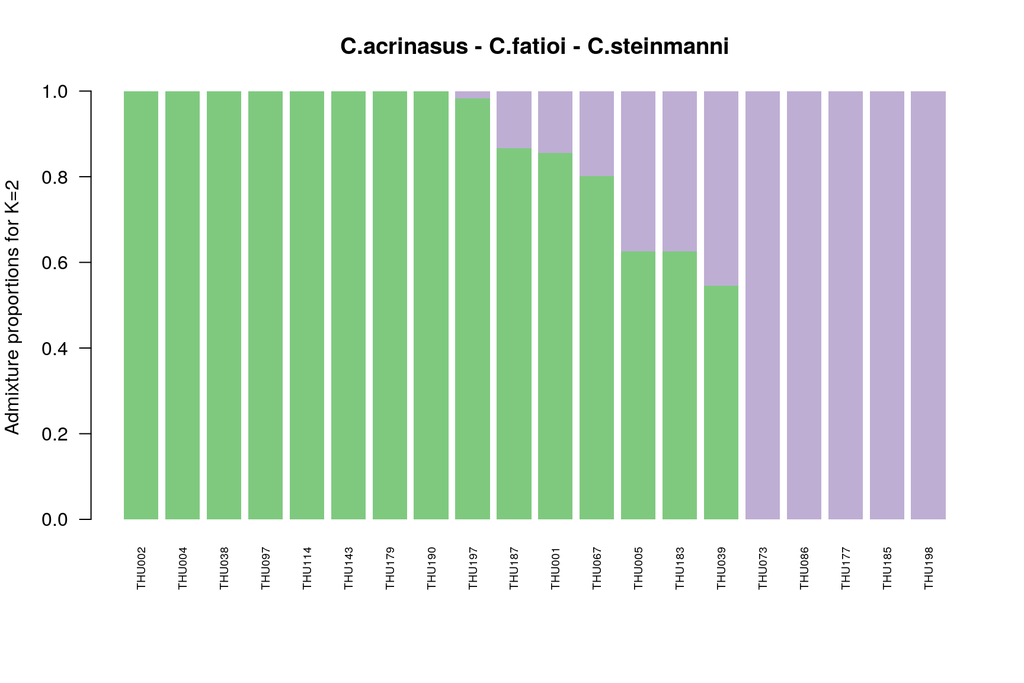

[output not shown]

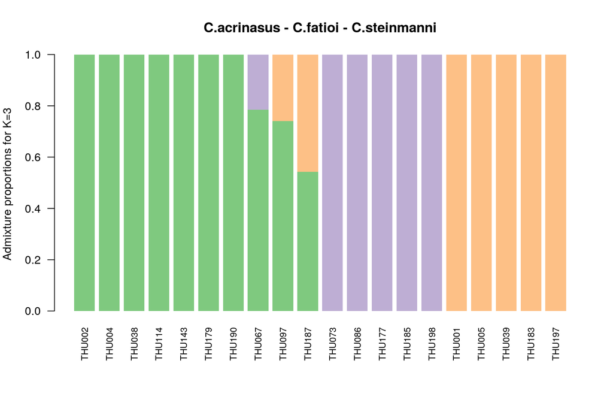

[output not shown]

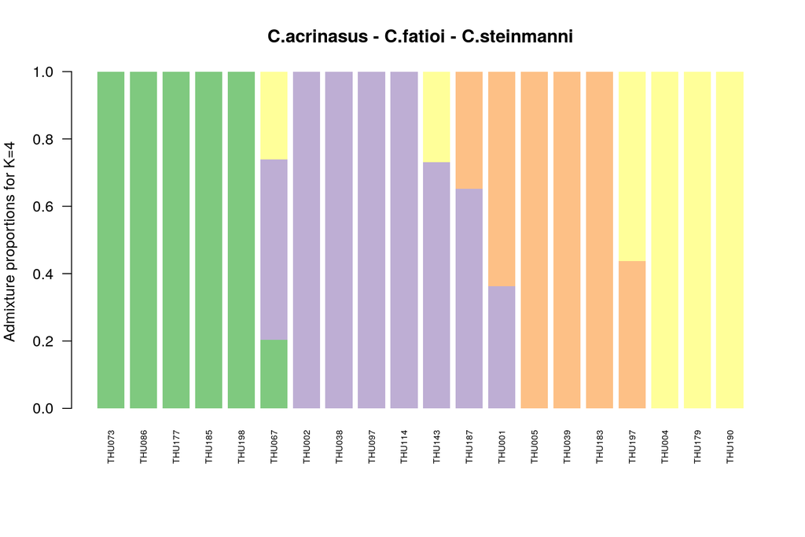

### C.acrinasus - C.fatioi

#### Removing species with less than 10 individuals/samples

Additionally, keep only those species that are present in lakes Brienz and Thun.

```r
poptable <- read.table('~/cophyhopa/data/popmap.txt',
                       col.names = c('sample', 'group', 'pop', 'lake'))

poptable <- poptable[-which(poptable[,3] == "C.alpinus"), ]
poptable <- poptable[-which(poptable[,3] == "C.alpinus/C.steinmanni"), ]
poptable <- poptable[-which(poptable[,3] == "C.brienzii"), ]
poptable <- poptable[-which(poptable[,3] == "C.fatioi/C.albellus"), ]
poptable <- poptable[-which(poptable[,3] == "D"), ]
poptable <- poptable[-which(poptable[,3] == "L"), ]
poptable <- poptable[-which(poptable[,3] == "P"), ]
poptable <- poptable[-which(poptable[,3] == "C.duplex"), ]
poptable <- poptable[-which(poptable[,3] == "C.heglingus"), ]
poptable <- poptable[-which(poptable[,3] == "C.zuerichensis"), ]
poptable <- poptable[-which(poptable[,3] == "C.confusus"), ]
poptable <- poptable[-which(poptable[,3] == "C.brienzii/C.fatioi"), ]

poptable <- poptable[-which(poptable[,3] == "C.steinmanni"), ]
poptable <- poptable[-which(poptable[,3] == "C.profundus"), ]
poptable <- poptable[-which(poptable[,3] == "C.albellus"), ]

write.table(poptable[,1], file = '~/cophyhopa/data/ADMX/BT_af.txt', quote = FALSE,
            row.names = FALSE, col.names = FALSE)
```

#### Data selecting and filtering

```bash
VCF='/gata/mar/cophyhopa/results/2022-05-04/assem2_indv2.recode.vcf'
FILE=BT_af
if [ ! -e $FILE.vcf.gz ]; then
   vcftools --vcf $VCF \
            --out dirty \
            --keep ~/cophyhopa/data/ADMX/BT_af.txt \
            --recode \
            --recode-INFO-all
   vcftools --vcf dirty.recode.vcf \
            --out $FILE \
            --thin 500 \
            --remove-indels \
            --mac 2 \
            --max-alleles 2 \
            --max-meanDP 1000 \
            --max-missing-count 7 \
            --stdout \
            --recode --recode-INFO-all \
            | gzip > $FILE.vcf.gz
fi
if [ -e dirty.recode.vcf ]; then rm dirty.recode.vcf; fi

if [ ! -e chromMap.txt ]; then
   gunzip -c $FILE".vcf.gz" | \
   gawk '(/^[^#]/){
      A[$1] = 1
   }END{
      N = 1
      for (chr in A) {
         print chr "\t" N
         N = N + 1
      }
   }' > chromMap.txt
fi

vcftools --gzvcf $FILE".vcf.gz" \
         --plink --mac 2 --remove-indels --max-alleles 2 \
         --chrom-map chromMap.txt \
         --out $FILE

gawk -v OFS="\t" '{
   $1 = 1
   $2 = 1 ":" $4
   print $0
}' $FILE".map" > better.map
mv better.map $FILE.map

plink --file $FILE --make-bed --out $FILE --allow-no-sex --allow-extra-chr 0
```

```
##
## VCFtools - 0.1.17
## (C) Adam Auton and Anthony Marcketta 2009
##
## Parameters as interpreted:
##  --vcf /gata/mar/cophyhopa/results/2022-05-04/assem2_indv2.recode.vcf
##  --keep /gata/mar/cophyhopa/data/ADMX/BT_af.txt
##  --recode-INFO-all
##  --out dirty
##  --recode
##
## Keeping individuals in 'keep' list
## After filtering, kept 20 out of 271 Individuals
## Outputting VCF file...
## After filtering, kept 879238 out of a possible 879238 Sites
## Run Time = 87.00 seconds
##
## VCFtools - 0.1.17
## (C) Adam Auton and Anthony Marcketta 2009
##
## Parameters as interpreted:
##  --vcf dirty.recode.vcf
##  --recode-INFO-all
##  --mac 2
##  --max-alleles 2
##  --max-missing-count 7
##  --max-meanDP 1e+03
##  --thin 500
##  --out BT_af
##  --recode
##  --remove-indels
##  --stdout
##
## After filtering, kept 20 out of 20 Individuals
## Outputting VCF file...
## After filtering, kept 32521 out of a possible 879238 Sites
## Run Time = 9.00 seconds
##
## VCFtools - 0.1.17
## (C) Adam Auton and Anthony Marcketta 2009
```

[output cut: 29 more lines]

```
.ped scan complete (for binary autoconversion).
## Performing single-pass .bed write (32521 variants, 20 people).
## 0%1%2%3%4%5%6%7%8%9%10%11%12%13%14%15%16%17%18%19%20%21%22%23%24%25%26%27%28%29%30%31%32%33%34%35%36%37%38%39%40%41%42%43%44%45%46%47%48%49%50%51%52%53%54%55%56%57%58%59%60%61%62%63%64%65%66%67%68%69%70%71%72%73%74%75%76%77%78%79%80%81%82%83%84%85%86%87%88%89%90%91%92%93%94%
--file: BT_af-temporary.bed + BT_af-temporary.bim + BT_af-temporary.fam
## written.
## 32521 variants loaded from .bim file.
## 20 people (0 males, 0 females, 20 ambiguous) loaded from .fam.
## Ambiguous sex IDs written to BT_af.nosex .
## Using 1 thread (no multithreaded calculations invoked).
## Before main variant filters, 20 founders and 0 nonfounders present.
## Calculating allele frequencies... 0%1%2%3%4%5%6%7%8%9%10%11%12%13%14%15%16%17%18%19%20%21%22%23%24%25%26%27%28%29%30%31%32%33%34%35%36%37%38%39%40%41%42%43%44%45%46%47%48%49%50%51%52%53%54%55%56%57%58%59%60%61%62%63%64%65%66%67%68%69%70%71%72%73%74%75%76%77%78%79%80%81%82%83%84%85%86%87%88%89%90%…
## Total genotyping rate is 0.954386.
## 32521 variants and 20 people pass filters and QC.
## Note: No phenotypes present.
## --make-bed to BT_af.bed + BT_af.bim + BT_af.fam ... 0%1%2%3%4%5%6%7%8%9%10%11%12%13%14%15%16%17%18%19%20%21%22%23%24%25%26%27%28%29%30%31%32%33%34%35%36%37%38%39%40%41%42%43%44%45%46%47%48%49%50%51%52%53%54%55%56%57%58%59%60%61%62%63%64%65%66%67%68%69%70%71%72%73%74%75%76%77%78%79%80%81%82%83%84%…
```

#### Admixture analysis with variant K

We define the K parameter from 2 to 3, computing the cross-validation error. Then, we extract these values.

```bash
INPUT='/gata/mar/cophyhopa/results/2022-05-09/admixture/ALPINE/BT_af.bed'

for K in 2 3; do
  if [ ! -e log${K}.BT_af.out ]; then
    admixture --cv $INPUT $K | tee log${K}.BT_af.out;
  fi
done
```

```bash
grep -h CV log*.BT_af.out
```

```
## CV error (K=2): 0.76311
## CV error (K=3): 1.09436
```

#### Plot Q estimates for K = 2 and 3

We choose the K that has given a lower value of the cross-validation error. We add the sample names and display a barplot.

[output not shown]

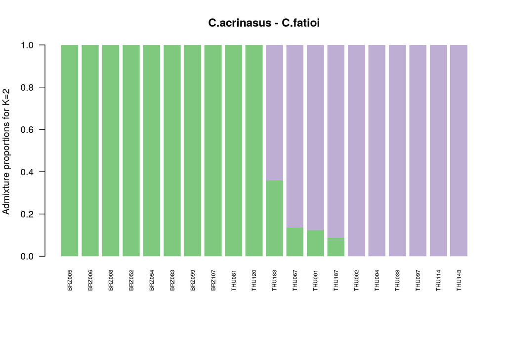

[output not shown]

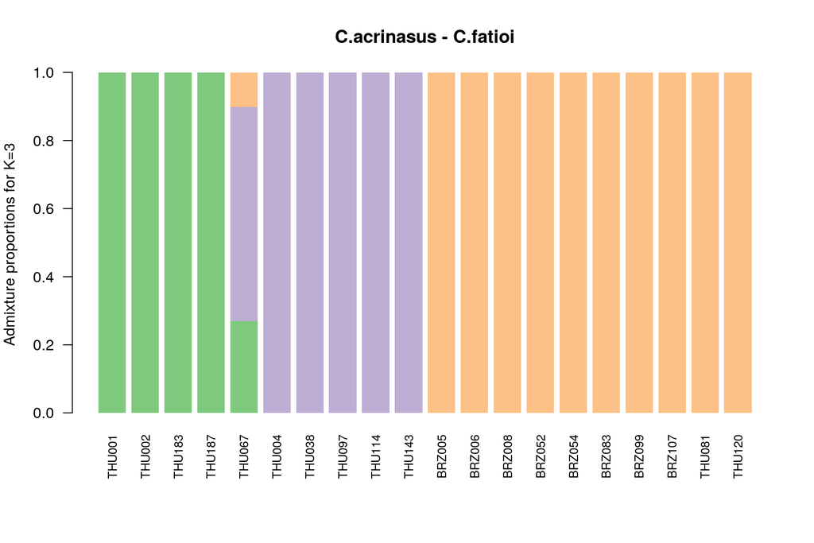

## Lakes Brienz, Thun and Bienne

### C.acrinasus - C.fatioi - C.albellus - C.profundus - C.steinmanni - C.confusus

We add C.confusus, the only species in lake Bienne.

#### Removing species with less than 10 individuals/samples

```r
poptable <- read.table('~/cophyhopa/data/popmap.txt',
                       col.names = c('sample', 'group', 'pop', 'lake'))

poptable <- poptable[-which(poptable[,3] == "C.alpinus"), ]
poptable <- poptable[-which(poptable[,3] == "C.alpinus/C.steinmanni"), ]
poptable <- poptable[-which(poptable[,3] == "C.brienzii"), ]
poptable <- poptable[-which(poptable[,3] == "C.fatioi/C.albellus"), ]
poptable <- poptable[-which(poptable[,3] == "D"), ]
poptable <- poptable[-which(poptable[,3] == "L"), ]
poptable <- poptable[-which(poptable[,3] == "P"), ]
poptable <- poptable[-which(poptable[,3] == "C.duplex"), ]
poptable <- poptable[-which(poptable[,3] == "C.heglingus"), ]
poptable <- poptable[-which(poptable[,3] == "C.zuerichensis"), ]
poptable <- poptable[-which(poptable[,3] == "C.brienzii/C.fatioi"), ]

write.table(poptable[,1], file = '~/cophyhopa/data/ADMX/BTB_all.txt', quote = FALSE,
            row.names = FALSE, col.names = FALSE)
```

#### Data selecting and filtering

```bash
VCF='/gata/mar/cophyhopa/results/2022-05-04/assem2_indv2.recode.vcf'
FILE=BTB_all
if [ ! -e $FILE.vcf.gz ]; then
   vcftools --vcf $VCF \
            --out dirty \
            --keep ~/cophyhopa/data/ADMX/BTB_all.txt \
            --recode \
            --recode-INFO-all
   vcftools --vcf dirty.recode.vcf \
            --out $FILE \
            --thin 500 \
            --remove-indels \
            --mac 2 \
            --max-alleles 2 \
            --max-meanDP 1000 \
            --max-missing-count 7 \
            --stdout \
            --recode --recode-INFO-all \
            | gzip > $FILE.vcf.gz
fi
if [ -e dirty.recode.vcf ]; then rm dirty.recode.vcf; fi

if [ ! -e chromMap.txt ]; then
   gunzip -c $FILE".vcf.gz" | \
   gawk '(/^[^#]/){
      A[$1] = 1
   }END{
      N = 1
      for (chr in A) {
         print chr "\t" N
         N = N + 1
      }
   }' > chromMap.txt
fi

vcftools --gzvcf $FILE".vcf.gz" \
         --plink --mac 2 --remove-indels --max-alleles 2 \
         --chrom-map chromMap.txt \
         --out $FILE

gawk -v OFS="\t" '{
   $1 = 1
   $2 = 1 ":" $4
   print $0
}' $FILE".map" > better.map
mv better.map $FILE.map

plink --file $FILE --make-bed --out $FILE --allow-no-sex --allow-extra-chr 0
```

```
##
## VCFtools - 0.1.17
## (C) Adam Auton and Anthony Marcketta 2009
##
## Parameters as interpreted:
##  --vcf /gata/mar/cophyhopa/results/2022-05-04/assem2_indv2.recode.vcf
##  --keep /gata/mar/cophyhopa/data/ADMX/BTB_all.txt
##  --recode-INFO-all
##  --out dirty
##  --recode
##
## Keeping individuals in 'keep' list
## After filtering, kept 94 out of 271 Individuals
## Outputting VCF file...
## After filtering, kept 879238 out of a possible 879238 Sites
## Run Time = 132.00 seconds
##
## VCFtools - 0.1.17
## (C) Adam Auton and Anthony Marcketta 2009
##
## Parameters as interpreted:
##  --vcf dirty.recode.vcf
##  --recode-INFO-all
##  --mac 2
##  --max-alleles 2
##  --max-missing-count 7
##  --max-meanDP 1e+03
##  --thin 500
##  --out BTB_all
##  --recode
##  --remove-indels
##  --stdout
##
## After filtering, kept 94 out of 94 Individuals
## Outputting VCF file...
## After filtering, kept 21907 out of a possible 879238 Sites
## Run Time = 27.00 seconds
##
## VCFtools - 0.1.17
## (C) Adam Auton and Anthony Marcketta 2009
```

[output cut: 29 more lines]

```
.ped scan complete (for binary autoconversion).
## Performing single-pass .bed write (21907 variants, 94 people).
## 0%1%2%3%4%5%6%7%8%9%10%11%12%13%14%15%16%17%18%19%20%21%22%23%24%25%26%27%28%29%30%31%32%33%34%35%36%37%38%39%40%41%42%43%44%45%46%47%48%49%50%51%52%53%54%55%56%57%58%59%60%61%62%63%64%65%66%67%68%69%70%71%72%73%74%75%76%77%78%79%80%81%82%83%84%85%86%87%88%89%90%91%92%93%94%
--file: BTB_all-temporary.bed + BTB_all-temporary.bim + BTB_all-temporary.fam
## written.
## 21907 variants loaded from .bim file.
## 94 people (0 males, 0 females, 94 ambiguous) loaded from .fam.
## Ambiguous sex IDs written to BTB_all.nosex .
## Using 1 thread (no multithreaded calculations invoked).
## Before main variant filters, 94 founders and 0 nonfounders present.
## Calculating allele frequencies... 0%1%2%3%4%5%6%7%8%9%10%11%12%13%14%15%16%17%18%19%20%21%22%23%24%25%26%27%28%29%30%31%32%33%34%35%36%37%38%39%40%41%42%43%44%45%46%47%48%49%50%51%52%53%54%55%56%57%58%59%60%61%62%63%64%65%66%67%68%69%70%71%72%73%74%75%76%77%78%79%80%81%82%83%84%85%86%87%88%89%90%…
## Total genotyping rate is 0.989697.
## 21907 variants and 94 people pass filters and QC.
## Note: No phenotypes present.
## --make-bed to BTB_all.bed + BTB_all.bim + BTB_all.fam ... 0%1%2%3%4%5%6%7%8%9%10%11%12%13%14%15%16%17%18%19%20%21%22%23%24%25%26%27%28%29%30%31%32%33%34%35%36%37%38%39%40%41%42%43%44%45%46%47%48%49%50%51%52%53%54%55%56%57%58%59%60%61%62%63%64%65%66%67%68%69%70%71%72%73%74%75%76%77%78%79%80%81%82%…
```

#### Admixture analysis with variant K

We define the K parameter from 4 to 6, computing the cross-validation error. Then, we extract these values.

```bash
INPUT='/gata/mar/cophyhopa/results/2022-05-09/admixture/ALPINE/BTB_all.bed'

for K in 4 5 6; do
  if [ ! -e log${K}.BTB_all.out ]; then
    admixture --cv $INPUT $K | tee log${K}.BTB_all.out;
  fi
done
```

```bash
grep -h CV log*.BTB_all.out
```

```
## CV error (K=4): 0.40809
## CV error (K=5): 0.42337
## CV error (K=6): 0.44290
```

#### Plot Q estimates for K = 4, 5 and 6

We choose the K that has given a lower value of the cross-validation error. We add the sample names and display a barplot

[output not shown]

[output cut: 132 more lines]

[output not shown]

[figure not shown]

[output not shown]

[output cut: 132 more lines]

[output not shown]

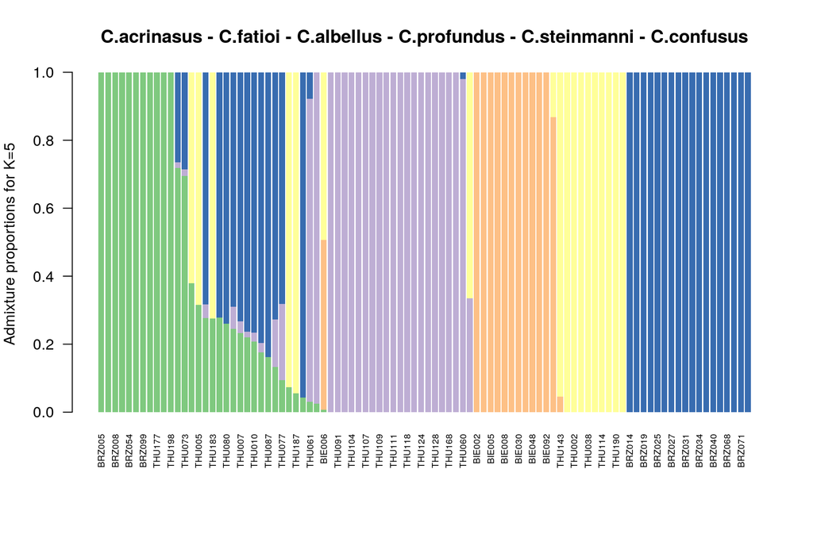

[output not shown]

[output cut: 132 more lines]

[output not shown]

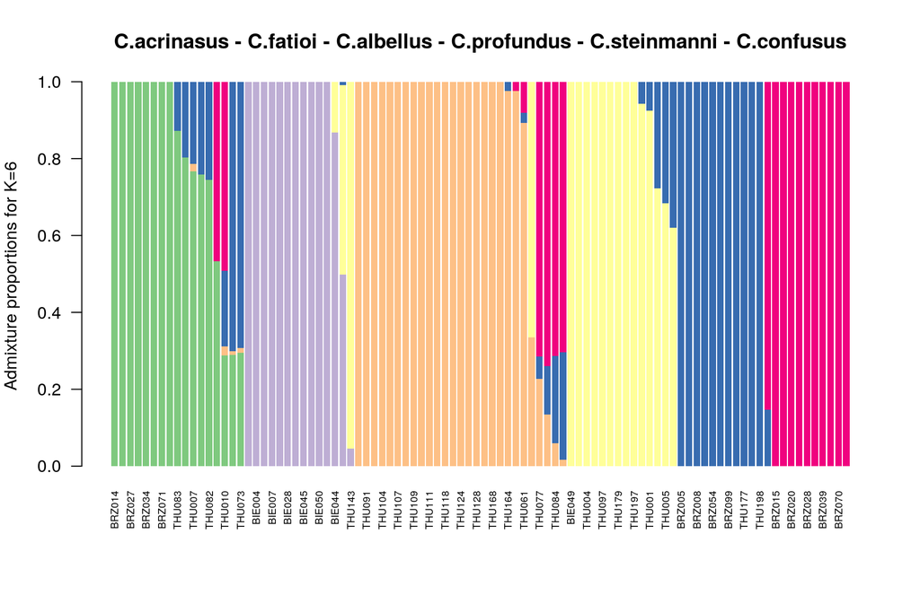

### C.acrinasus - C.fatioi - C.albellus - C.profundus - C.confusus

We add C.confusus, the only species in lake Bienne, and exclude C.steinmanni.

#### Removing species with less than 10 individuals/samples

```r
poptable <- read.table('~/cophyhopa/data/popmap.txt',
                       col.names = c('sample', 'group', 'pop', 'lake'))

poptable <- poptable[-which(poptable[,3] == "C.alpinus"), ]
poptable <- poptable[-which(poptable[,3] == "C.alpinus/C.steinmanni"), ]
poptable <- poptable[-which(poptable[,3] == "C.brienzii"), ]
poptable <- poptable[-which(poptable[,3] == "C.fatioi/C.albellus"), ]
poptable <- poptable[-which(poptable[,3] == "D"), ]
poptable <- poptable[-which(poptable[,3] == "L"), ]
poptable <- poptable[-which(poptable[,3] == "P"), ]
poptable <- poptable[-which(poptable[,3] == "C.duplex"), ]
poptable <- poptable[-which(poptable[,3] == "C.heglingus"), ]
poptable <- poptable[-which(poptable[,3] == "C.zuerichensis"), ]
poptable <- poptable[-which(poptable[,3] == "C.brienzii/C.fatioi"), ]

poptable <- poptable[-which(poptable[,3] == "C.steinmanni"), ]


write.table(poptable[,1], file = '~/cophyhopa/data/ADMX/BTB_afapc.txt', quote = FALSE,
            row.names = FALSE, col.names = FALSE)
```

#### Data selecting and filtering

```bash
VCF='/gata/mar/cophyhopa/results/2022-05-04/assem2_indv2.recode.vcf'
FILE=BTB_afapc
if [ ! -e $FILE.vcf.gz ]; then
   vcftools --vcf $VCF \
            --out dirty \
            --keep ~/cophyhopa/data/ADMX/BTB_afapc.txt \
            --recode \
            --recode-INFO-all
   vcftools --vcf dirty.recode.vcf \
            --out $FILE \
            --thin 500 \
            --remove-indels \
            --mac 2 \
            --max-alleles 2 \
            --max-meanDP 1000 \
            --max-missing-count 7 \
            --stdout \
            --recode --recode-INFO-all \
            | gzip > $FILE.vcf.gz
fi
if [ -e dirty.recode.vcf ]; then rm dirty.recode.vcf; fi

if [ ! -e chromMap.txt ]; then
   gunzip -c $FILE".vcf.gz" | \
   gawk '(/^[^#]/){
      A[$1] = 1
   }END{
      N = 1
      for (chr in A) {
         print chr "\t" N
         N = N + 1
      }
   }' > chromMap.txt
fi

vcftools --gzvcf $FILE".vcf.gz" \
         --plink --mac 2 --remove-indels --max-alleles 2 \
         --chrom-map chromMap.txt \
         --out $FILE

gawk -v OFS="\t" '{
   $1 = 1
   $2 = 1 ":" $4
   print $0
}' $FILE".map" > better.map
mv better.map $FILE.map

plink --file $FILE --make-bed --out $FILE --allow-no-sex --allow-extra-chr 0
```

```
##
## VCFtools - 0.1.17
## (C) Adam Auton and Anthony Marcketta 2009
##
## Parameters as interpreted:
##  --vcf /gata/mar/cophyhopa/results/2022-05-04/assem2_indv2.recode.vcf
##  --keep /gata/mar/cophyhopa/data/ADMX/BTB_afapc.txt
##  --recode-INFO-all
##  --out dirty
##  --recode
##
## Keeping individuals in 'keep' list
## After filtering, kept 84 out of 271 Individuals
## Outputting VCF file...
## After filtering, kept 879238 out of a possible 879238 Sites
## Run Time = 130.00 seconds
##
## VCFtools - 0.1.17
## (C) Adam Auton and Anthony Marcketta 2009
##
## Parameters as interpreted:
##  --vcf dirty.recode.vcf
##  --recode-INFO-all
##  --mac 2
##  --max-alleles 2
##  --max-missing-count 7
##  --max-meanDP 1e+03
##  --thin 500
##  --out BTB_afapc
##  --recode
##  --remove-indels
##  --stdout
##
## After filtering, kept 84 out of 84 Individuals
## Outputting VCF file...
## After filtering, kept 21909 out of a possible 879238 Sites
## Run Time = 24.00 seconds
##
## VCFtools - 0.1.17
## (C) Adam Auton and Anthony Marcketta 2009
```

[output cut: 29 more lines]

```
.ped scan complete (for binary autoconversion).
## Performing single-pass .bed write (21909 variants, 84 people).
## 0%1%2%3%4%5%6%7%8%9%10%11%12%13%14%15%16%17%18%19%20%21%22%23%24%25%26%27%28%29%30%31%32%33%34%35%36%37%38%39%40%41%42%43%44%45%46%47%48%49%50%51%52%53%54%55%56%57%58%59%60%61%62%63%64%65%66%67%68%69%70%71%72%73%74%75%76%77%78%79%80%81%82%83%84%85%86%87%88%89%90%91%92%93%94%
--file: BTB_afapc-temporary.bed + BTB_afapc-temporary.bim +
## BTB_afapc-temporary.fam written.
## 21909 variants loaded from .bim file.
## 84 people (0 males, 0 females, 84 ambiguous) loaded from .fam.
## Ambiguous sex IDs written to BTB_afapc.nosex .
## Using 1 thread (no multithreaded calculations invoked).
## Before main variant filters, 84 founders and 0 nonfounders present.
## Calculating allele frequencies... 0%1%2%3%4%5%6%7%8%9%10%11%12%13%14%15%16%17%18%19%20%21%22%23%24%25%26%27%28%29%30%31%32%33%34%35%36%37%38%39%40%41%42%43%44%45%46%47%48%49%50%51%52%53%54%55%56%57%58%59%60%61%62%63%64%65%66%67%68%69%70%71%72%73%74%75%76%77%78%79%80%81%82%83%84%85%86%87%88%89%90%…
## Total genotyping rate is 0.988453.
## 21909 variants and 84 people pass filters and QC.
## Note: No phenotypes present.
## --make-bed to BTB_afapc.bed + BTB_afapc.bim + BTB_afapc.fam ... 0%1%2%3%4%5%6%7%8%9%10%11%12%13%14%15%16%17%18%19%20%21%22%23%24%25%26%27%28%29%30%31%32%33%34%35%36%37%38%39%40%41%42%43%44%45%46%47%48%49%50%51%52%53%54%55%56%57%58%59%60%61%62%63%64%65%66%67%68%69%70%71%72%73%74%75%76%77%78%79%80%…
```

#### Admixture analysis with variant K

```bash
INPUT='/gata/mar/cophyhopa/results/2022-05-09/admixture/ALPINE/BTB_afapc.bed'

for K in 4 5 6; do
  if [ ! -e log${K}.BTB_afapc.out ]; then
    admixture --cv $INPUT $K | tee log${K}.BTB_afapc.out;
  fi
done
```

```bash
grep -h CV log*.BTB_afapc.out
```

```
## CV error (K=4): 0.42867
## CV error (K=5): 0.44970
## CV error (K=6): 0.47040
```

#### Plot Q estimates for K = 4, 5 and 6

We choose the K that has given a lower value of the cross-validation error. We add the sample names and display a barplot

[output not shown]

[output cut: 112 more lines]

[output not shown]

[figure not shown]

[output not shown]

[output cut: 112 more lines]

[output not shown]

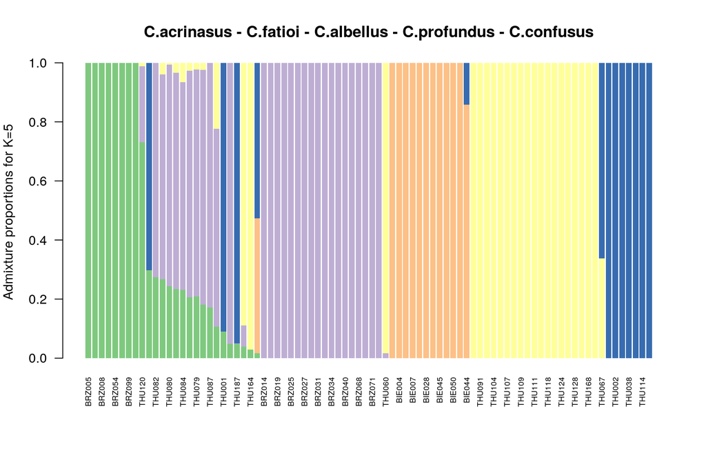

[output not shown]

[output cut: 112 more lines]

[output not shown]

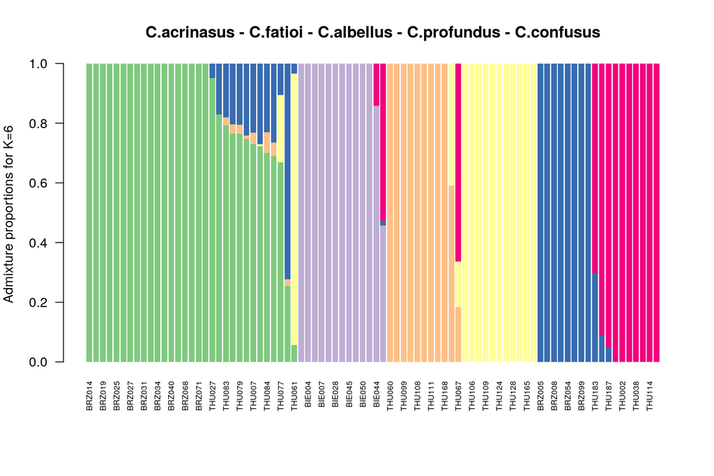

## All Alpine lakes

#### Removing species with less than 10 individuals/samples

```r
poptable <- read.table('~/cophyhopa/data/popmap.txt',
                       col.names = c('sample', 'group', 'pop', 'lake'))

poptable <- poptable[-which(poptable[,3] == "C.alpinus"), ]
poptable <- poptable[-which(poptable[,3] == "C.alpinus/C.steinmanni"), ]
poptable <- poptable[-which(poptable[,3] == "C.brienzii"), ]
poptable <- poptable[-which(poptable[,3] == "C.fatioi/C.albellus"), ]
poptable <- poptable[-which(poptable[,3] == "D"), ]
poptable <- poptable[-which(poptable[,3] == "L"), ]
poptable <- poptable[-which(poptable[,3] == "P"), ]
poptable <- poptable[-which(poptable[,3] == "C.brienzii/C.fatioi"), ]

write.table(poptable[,1], file = '~/cophyhopa/data/ADMX/ALL.txt', quote = FALSE,
            row.names = FALSE, col.names = FALSE)
```

#### Data selecting and filtering

```bash
VCF='/gata/mar/cophyhopa/results/2022-05-04/assem2_indv2.recode.vcf'
FILE=ALL
if [ ! -e $FILE.vcf.gz ]; then
   vcftools --vcf $VCF \
            --out dirty \
            --keep ~/cophyhopa/data/ADMX/ALL.txt \
            --recode \
            --recode-INFO-all
   vcftools --vcf dirty.recode.vcf \
            --out $FILE \
            --thin 500 \
            --remove-indels \
            --mac 2 \
            --max-alleles 2 \
            --max-meanDP 1000 \
            --max-missing-count 7 \
            --stdout \
            --recode --recode-INFO-all \
            | gzip > $FILE.vcf.gz
fi
if [ -e dirty.recode.vcf ]; then rm dirty.recode.vcf; fi

if [ ! -e chromMap.txt ]; then
   gunzip -c $FILE".vcf.gz" | \
   gawk '(/^[^#]/){
      A[$1] = 1
   }END{
      N = 1
      for (chr in A) {
         print chr "\t" N
         N = N + 1
      }
   }' > chromMap.txt
fi

vcftools --gzvcf $FILE".vcf.gz" \
         --plink --mac 2 --remove-indels --max-alleles 2 \
         --chrom-map chromMap.txt \
         --out $FILE

gawk -v OFS="\t" '{
   $1 = 1
   $2 = 1 ":" $4
   print $0
}' $FILE".map" > better.map
mv better.map $FILE.map

plink --file $FILE --make-bed --out $FILE --allow-no-sex --allow-extra-chr 0
```

```
##
## VCFtools - 0.1.17
## (C) Adam Auton and Anthony Marcketta 2009
##
## Parameters as interpreted:
##  --vcf /gata/mar/cophyhopa/results/2022-05-04/assem2_indv2.recode.vcf
##  --keep /gata/mar/cophyhopa/data/ADMX/ALL.txt
##  --recode-INFO-all
##  --out dirty
##  --recode
##
## Keeping individuals in 'keep' list
## After filtering, kept 142 out of 271 Individuals
## Outputting VCF file...
## After filtering, kept 879238 out of a possible 879238 Sites
## Run Time = 163.00 seconds
##
## VCFtools - 0.1.17
## (C) Adam Auton and Anthony Marcketta 2009
##
## Parameters as interpreted:
##  --vcf dirty.recode.vcf
##  --recode-INFO-all
##  --mac 2
##  --max-alleles 2
##  --max-missing-count 7
##  --max-meanDP 1e+03
##  --thin 500
##  --out ALL
##  --recode
##  --remove-indels
##  --stdout
##
## After filtering, kept 142 out of 142 Individuals
## Outputting VCF file...
## After filtering, kept 21641 out of a possible 879238 Sites
## Run Time = 38.00 seconds
##
## VCFtools - 0.1.17
## (C) Adam Auton and Anthony Marcketta 2009
```

[output cut: 28 more lines]

```
## Scanning .ped file... 0%1%2%2%3%4%4%5%6%7%7%8%9%9%10%11%11%12%13%14%14%15%16%16%17%18%19%19%20%21%21%22%23%23%24%25%26%26%27%28%28%29%30%30%31%32%33%33%34%35%35%36%37%38%38%39%40%40%41%42%42%43%44%45%45%46%47%47%48%49%50%50%51%52%52%53%54%54%55%56%57%57%58%59%59%60%61%61%62%63%64%64%65%66%66%67%6…
.ped scan complete (for binary autoconversion).
## Performing single-pass .bed write (21641 variants, 142 people).
## 0%1%2%3%4%5%6%7%8%9%10%11%12%13%14%15%16%17%18%19%20%21%22%23%24%25%26%27%28%29%30%31%32%33%34%35%36%37%38%39%40%41%42%43%44%45%46%47%48%49%50%51%52%53%54%55%56%57%58%59%60%61%62%63%64%65%66%67%68%69%70%71%72%73%74%75%76%77%78%79%80%81%82%83%84%85%86%87%88%89%90%91%92%93%94%
--file: ALL-temporary.bed + ALL-temporary.bim + ALL-temporary.fam written.
## 21641 variants loaded from .bim file.
## 142 people (0 males, 0 females, 142 ambiguous) loaded from .fam.
## Ambiguous sex IDs written to ALL.nosex .
## Using 1 thread (no multithreaded calculations invoked).
## Before main variant filters, 142 founders and 0 nonfounders present.
## Calculating allele frequencies... 0%1%2%3%4%5%6%7%8%9%10%11%12%13%14%15%16%17%18%19%20%21%22%23%24%25%26%27%28%29%30%31%32%33%34%35%36%37%38%39%40%41%42%43%44%45%46%47%48%49%50%51%52%53%54%55%56%57%58%59%60%61%62%63%64%65%66%67%68%69%70%71%72%73%74%75%76%77%78%79%80%81%82%83%84%85%86%87%88%89%90%…
## Total genotyping rate is 0.992589.
## 21641 variants and 142 people pass filters and QC.
## Note: No phenotypes present.
## --make-bed to ALL.bed + ALL.bim + ALL.fam ... 0%1%2%3%4%5%6%7%8%9%10%11%12%13%14%15%16%17%18%19%20%21%22%23%24%25%26%27%28%29%30%31%32%33%34%35%36%37%38%39%40%41%42%43%44%45%46%47%48%49%50%51%52%53%54%55%56%57%58%59%60%61%62%63%64%65%66%67%68%69%70%71%72%73%74%75%76%77%78%79%80%81%82%83%84%85%86%…
```

#### Admixture analysis with variant K

We define the K parameter from 7 to 10, computing the cross-validation error. Then, we extract these values.

```bash
INPUT='/gata/mar/cophyhopa/results/2022-05-09/admixture/ALPINE/ALL.bed'

for K in 7 8 9 10; do
  if [ ! -e log${K}.ALL.out ]; then
    admixture --cv $INPUT $K | tee log${K}.ALL.out;
  fi
done
```

```bash
grep -h CV log*.ALL.out
```

```
## CV error (K=10): 0.40873
## CV error (K=7): 0.36292
## CV error (K=8): 0.37301
## CV error (K=9): 0.39715
```

#### Plot Q estimates for K = 7, 8, 9 and 10

We choose the K that has given a lower value of the cross-validation error. We add the sample names and display a barplot

[output not shown]

[output cut: 228 more lines]

[output not shown]

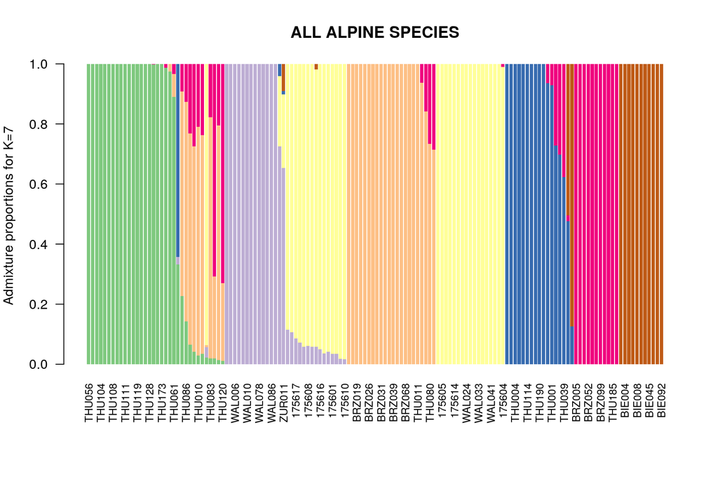

[output not shown]

[output cut: 228 more lines]

[output not shown]

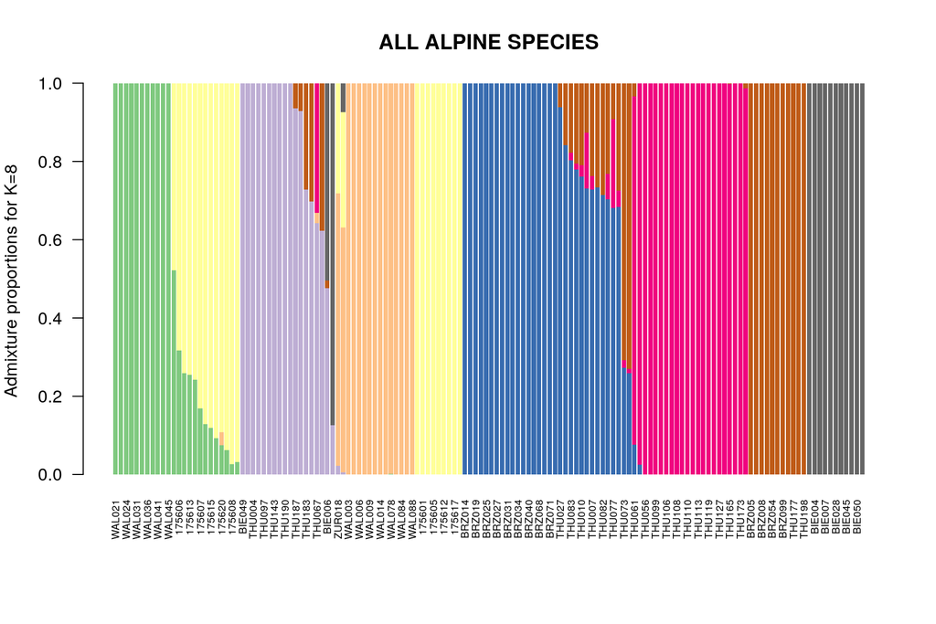

[output not shown]

[output cut: 228 more lines]

[output not shown]

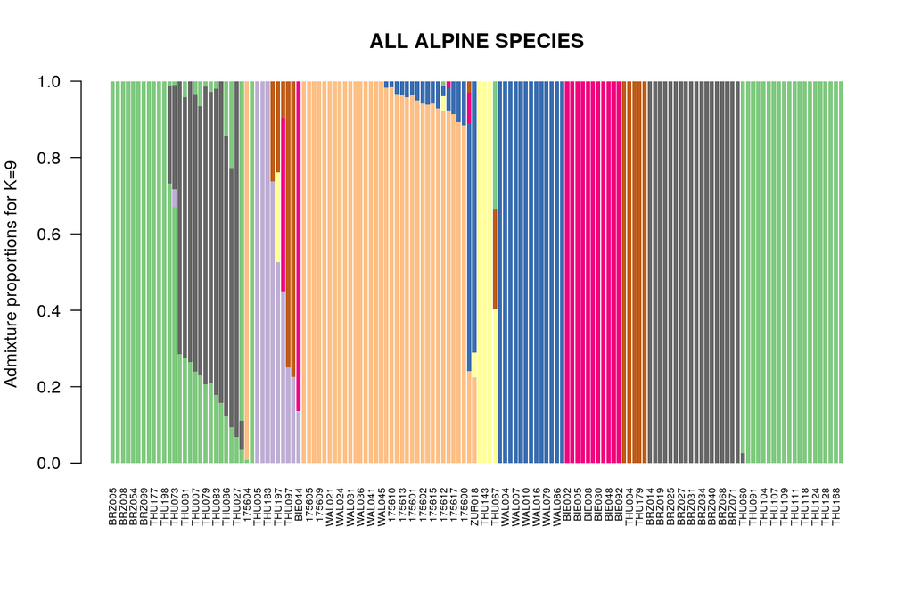

[output not shown]

[output cut: 228 more lines]

[output not shown]

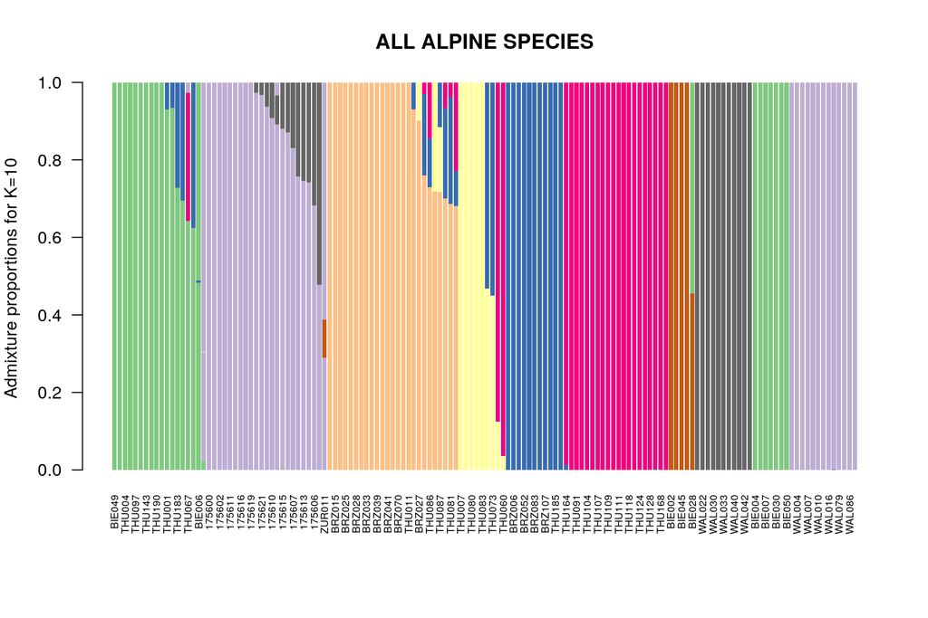

# Species in Arctic lakes

## Lakes Suohpatjavri and Langfjordvatn

#### Data selecting and filtering

```bash
VCF='/gata/mar/cophyhopa/results/2022-05-04/assem2_indv2.recode.vcf'
FILE=ARC
if [ ! -e $FILE.vcf.gz ]; then
   vcftools --vcf $VCF \
            --out dirty \
            --keep ~/cophyhopa/data/Arctic.txt \
            --recode \
            --recode-INFO-all
   vcftools --vcf dirty.recode.vcf \
            --out $FILE \
            --thin 500 \
            --remove-indels \
            --mac 2 \
            --max-alleles 2 \
            --max-meanDP 1000 \
            --max-missing-count 7 \
            --stdout \
            --recode --recode-INFO-all \
            | gzip > $FILE.vcf.gz
fi
if [ -e dirty.recode.vcf ]; then rm dirty.recode.vcf; fi

if [ ! -e chromMap.txt ]; then
   gunzip -c $FILE".vcf.gz" | \
   gawk '(/^[^#]/){
      A[$1] = 1
   }END{
      N = 1
      for (chr in A) {
         print chr "\t" N
         N = N + 1
      }
   }' > chromMap.txt
fi

vcftools --gzvcf $FILE".vcf.gz" \
         --plink --mac 2 --remove-indels --max-alleles 2 \
         --chrom-map chromMap.txt \
         --out $FILE

gawk -v OFS="\t" '{
   $1 = 1
   $2 = 1 ":" $4
   print $0
}' $FILE".map" > better.map
mv better.map $FILE.map

plink --file $FILE --make-bed --out $FILE --allow-no-sex --allow-extra-chr 0
```

```
##
## VCFtools - 0.1.17
## (C) Adam Auton and Anthony Marcketta 2009
##
## Parameters as interpreted:
##  --vcf /gata/mar/cophyhopa/results/2022-05-04/assem2_indv2.recode.vcf
##  --keep /gata/mar/cophyhopa/data/Arctic.txt
##  --recode-INFO-all
##  --out dirty
##  --recode
##
## Keeping individuals in 'keep' list
## After filtering, kept 114 out of 271 Individuals
## Outputting VCF file...
## After filtering, kept 879238 out of a possible 879238 Sites
## Run Time = 158.00 seconds
##
## VCFtools - 0.1.17
## (C) Adam Auton and Anthony Marcketta 2009
##
## Parameters as interpreted:
##  --vcf dirty.recode.vcf
##  --recode-INFO-all
##  --mac 2
##  --max-alleles 2
##  --max-missing-count 7
##  --max-meanDP 1e+03
##  --thin 500
##  --out ARC
##  --recode
##  --remove-indels
##  --stdout
##
## After filtering, kept 114 out of 114 Individuals
## Outputting VCF file...
## After filtering, kept 27225 out of a possible 879238 Sites
## Run Time = 33.00 seconds
##
## VCFtools - 0.1.17
## (C) Adam Auton and Anthony Marcketta 2009
```

[output cut: 28 more lines]

```
## Scanning .ped file... 0%1%2%3%4%5%6%7%7%8%9%10%11%12%13%14%14%15%16%17%18%19%20%21%21%22%23%24%25%26%27%28%28%29%30%31%32%33%34%35%35%36%37%38%39%40%41%42%42%43%44%45%46%47%48%49%50%50%51%52%53%54%55%56%57%57%58%59%60%61%62%63%64%64%65%66%67%68%69%70%71%71%72%73%74%75%76%77%78%78%79%80%81%82%83%8…
.ped scan complete (for binary autoconversion).
## Performing single-pass .bed write (27225 variants, 114 people).
## 0%1%2%3%4%5%6%7%8%9%10%11%12%13%14%15%16%17%18%19%20%21%22%23%24%25%26%27%28%29%30%31%32%33%34%35%36%37%38%39%40%41%42%43%44%45%46%47%48%49%50%51%52%53%54%55%56%57%58%59%60%61%62%63%64%65%66%67%68%69%70%71%72%73%74%75%76%77%78%79%80%81%82%83%84%85%86%87%88%89%90%91%92%93%94%
--file: ARC-temporary.bed + ARC-temporary.bim + ARC-temporary.fam written.
## 27225 variants loaded from .bim file.
## 114 people (0 males, 0 females, 114 ambiguous) loaded from .fam.
## Ambiguous sex IDs written to ARC.nosex .
## Using 1 thread (no multithreaded calculations invoked).
## Before main variant filters, 114 founders and 0 nonfounders present.
## Calculating allele frequencies... 0%1%2%3%4%5%6%7%8%9%10%11%12%13%14%15%16%17%18%19%20%21%22%23%24%25%26%27%28%29%30%31%32%33%34%35%36%37%38%39%40%41%42%43%44%45%46%47%48%49%50%51%52%53%54%55%56%57%58%59%60%61%62%63%64%65%66%67%68%69%70%71%72%73%74%75%76%77%78%79%80%81%82%83%84%85%86%87%88%89%90%…
## Total genotyping rate is 0.994153.
## 27225 variants and 114 people pass filters and QC.
## Note: No phenotypes present.
## --make-bed to ARC.bed + ARC.bim + ARC.fam ... 0%1%2%3%4%5%6%7%8%9%10%11%12%13%14%15%16%17%18%19%20%21%22%23%24%25%26%27%28%29%30%31%32%33%34%35%36%37%38%39%40%41%42%43%44%45%46%47%48%49%50%51%52%53%54%55%56%57%58%59%60%61%62%63%64%65%66%67%68%69%70%71%72%73%74%75%76%77%78%79%80%81%82%83%84%85%86%…
```

#### Admixture analysis with variant K

```bash
INPUT='/gata/mar/cophyhopa/results/2022-05-09/admixture/ALPINE/ARC.bed'

for K in 2 3 4 5; do
  if [ ! -e log${K}.ARC.out ]; then
    admixture --cv $INPUT $K | tee log${K}.ARC.out;
  fi
done
```

```bash
grep -h CV log*.ARC.out
```

```
## CV error (K=2): 0.36466
## CV error (K=3): 0.37365
## CV error (K=4): 0.36559
## CV error (K=5): 0.37387
```

We choose the K that has given a lower value of the cross-validation error. We add the sample names and display a barplot.

[output not shown]

[output cut: 172 more lines]

[output not shown]

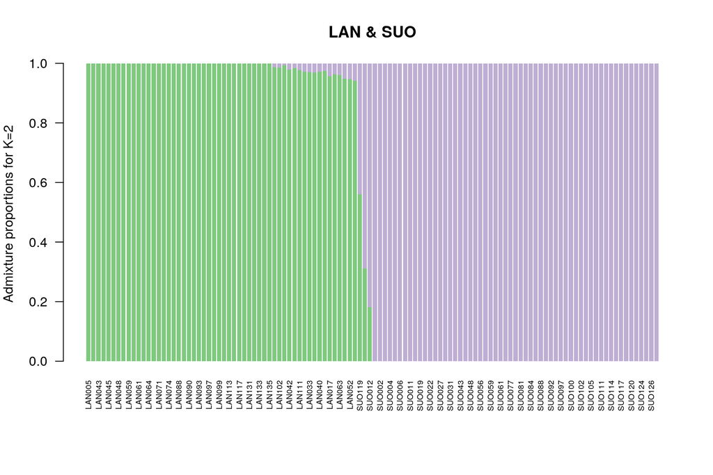

[output not shown]

[output cut: 172 more lines]

[output not shown]

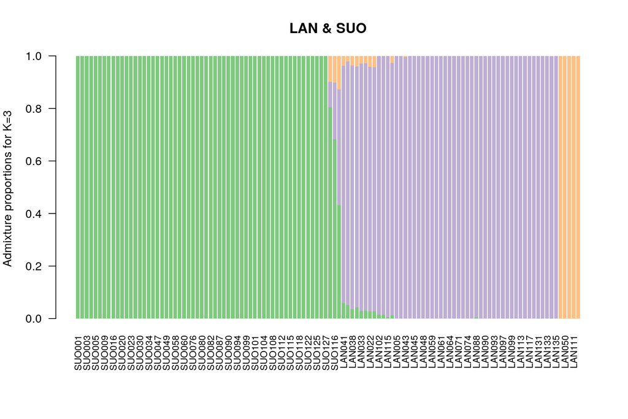